# Task 1 - data analysis

### data storage

In this part I need to store the annotations - JSON files, in a database of some kind. I probably would have chosen MongoDB, a document database, for storage. It is a popular, versitile, NoSQL database that is easy to use and has a worldwide supporting community and documentation. It also has an extensive SDK for Python, which makes it easy to use.

I would also reccomend AWS's DynamoDB, which is also a NoSQL database (although being a key-value one). It will be more available than MongoDB and will automatically scale.

I currently don't have the resources to start these environments, so I will make a downscale dataset of a few movies for the analysis. Specifically, the annotation data from the [SightX offices](https://drive.google.com/drive/folders/1iqJYRtRaTE1K6tgl2zOU8uStFDt1KofJ?usp=sharing) sub-directory. I have downloaded them to my computer and worked locally.

### data import and conversion

In this part I will convert the data from a JSON format into the following Pandas dataframes:

1. Movie_frames_df: stores the data for each frame, except for objects.
2. Movie_metadata_df: stores the first row of each movie - information about the movie itself.
3. Object_frames_df: stores the information about the objects in the movies, where and when they appear, and their different attributes.

```python
import json
import os
import numpy as np
import pandas as pd
import matplotlib.pyplot as plt
```

```python
json_dicts = []
for json_filename in os.listdir('./data'):
    with open(os.path.join('./data/',json_filename),'rb') as json_file:
        json_dicts.append(json.loads(json_file.read()))
```

### Metadata analysis:

```python
metadatas = [mv[0] for mv in json_dicts]
movie_metadata_df = pd.DataFrame(metadatas)
movie_metadata_df
```

|  | version | file | part | original_frame | frames | key_bb | keyframes | objects |
| --- | --- | --- | --- | --- | --- | --- | --- | --- |
| 0 | 1.3 | bulk_005/SIghtxOffice_2020_11_24/Sc802_Id0800_... | 1 | 1 | 314 | 0 | 0 | [{'nm': '0.1', 'type': 'person', 'shape': 'bBo... |
| 1 | 1.3 | bulk_005/SIghtxOffice_2020_11_24/Sc802_Id0800_... | 1 | 1 | 431 | 0 | 0 | [{'nm': '0.1', 'type': 'person', 'shape': 'bBo... |
| 2 | 1.3 | bulk_005/SIghtxOffice_2020_11_24/Sc802_Id0800_... | 1 | 1 | 234 | 0 | 0 | [{'nm': '0.1', 'type': 'person', 'shape': 'bBo... |
| 3 | 1.3 | bulk_005/SIghtxOffice_2020_11_24/Sc802_Id0800_... | 1 | 1 | 491 | 0 | 0 | [{'nm': '0.1', 'type': 'person', 'shape': 'bBo... |
| 4 | 1.3 | bulk_005/SIghtxOffice_2020_11_24/Sc802_Id0800_... | 1 | 1 | 606 | 0 | 0 | [{'nm': '0.1', 'type': 'person', 'shape': 'bBo... |

We can observe that the movies are not in the same lenght by looking in the number of frames. However, this variation won't hinder the training process if they all contain good data about the objects.

Speaking of which, let's look what objects are contained in the movies:

```python
[np.array(arr).flatten() for arr in np.array(movie_metadata_df['objects']).flatten()]
```

```
[array([{'nm': '0.1', 'type': 'person', 'shape': 'bBox', 'attributes': {'type': 'real_person'}},
        {'nm': '0.2', 'type': 'person', 'shape': 'bBox', 'attributes': {'type': 'real_person'}}],
       dtype=object),
 array([{'nm': '0.1', 'type': 'person', 'shape': 'bBox', 'attributes': {'type': 'real_person'}},
        {'nm': '0.2', 'type': 'person', 'shape': 'bBox', 'attributes': {'type': 'real_person'}}],
       dtype=object),
 array([{'nm': '0.1', 'type': 'person', 'shape': 'bBox', 'attributes': {'type': 'real_person'}},
        {'nm': '0.2', 'type': 'person', 'shape': 'bBox', 'attributes': {'type': 'real_person'}}],
       dtype=object),
 array([{'nm': '0.1', 'type': 'person', 'shape': 'bBox', 'attributes': {'type': 'real_person'}},
        {'nm': '0.2', 'type': 'person', 'shape': 'bBox', 'attributes': {'type': 'real_person'}},
        {'nm': '0.3', 'type': 'rifle', 'shape': 'bBox', 'attributes': {'type': 'ak47'}},
        {'nm': '0.4', 'type': 'rifle', 'shape': 'bBox', 'attributes': {'type': 'm16'}},
        {'nm': '0.5', 'type': 'rifle', 'shape': 'bBox', 'attributes': {'type': 'm16'}},
        {'nm': '0.6', 'type': 'rifle', 'shape': 'bBox', 'attributes': {'type': 'm16'}},
        {'nm': '0.7', 'type': 'rifle', 'shape': 'bBox', 'attributes': {'type': 'm16'}},
        {'nm': '0.9', 'type': 'rifle', 'shape': 'bBox', 'attributes': {'type': 'other'}},
        {'nm': '0.10', 'type': 'person', 'shape': 'bBox', 'attributes': {'type': 'other'}},
        {'nm': '0.11', 'type': 'rifle', 'shape': 'bBox', 'attributes': {'type': 'other'}},
        {'nm': '0.12', 'type': 'person', 'shape': 'bBox', 'attributes': {'type': 'other'}}],
       dtype=object),
 array([{'nm': '0.1', 'type': 'person', 'shape': 'bBox', 'attributes': {'type': 'real_person'}},
        {'nm': '0.2', 'type': 'person', 'shape': 'bBox', 'attributes': {'type': 'real_person'}},
        {'nm': '0.3', 'type': 'rifle', 'shape': 'bBox', 'attributes': {'type': 'm16'}},
        {'nm': '0.4', 'type': 'rifle', 'shape': 'bBox', 'attributes': {'type': 'm16'}},
        {'nm': '0.5', 'type': 'rifle', 'shape': 'bBox', 'attributes': {'type': 'm16'}},
        {'nm': '0.6', 'type': 'rifle', 'shape': 'bBox', 'attributes': {'type': 'ak47'}},
        {'nm': '0.7', 'type': 'person', 'shape': 'bBox', 'attributes': {'type': 'other'}},
        {'nm': '0.8', 'type': 'person', 'shape': 'bBox', 'attributes': {'type': 'other'}}],
       dtype=object)]
```

We can see that the distribution of rifle and person objects is about the same, however the person type has two sub-types, one of them is quite ambigeous (type='other').

Something else to notice is that the shape of the objects doesn't change. This is probably due to the annotaion method.

### Building the dataframes:

```python
object_col_names = []

def build_object_dict(objs, object_list, movie, frame):
    temp = {}
    for obj in objs:
        temp['movie'] = movie
        temp['frame'] = frame
        if 'attributes' in obj.keys():
            for k,v in obj['attributes'].items():
                temp[k] = v
                if k not in object_col_names:
                    object_col_names.append(k)

            obj.pop('attributes')
            for k,v in obj.items():
                temp[k] = v
                if k not in object_col_names:
                    object_col_names.append(k)
            object_list.append(temp)

    return object_list
```

```python
movie_frames = []
object_frames = []
for i in range(len(json_dicts)):
    for j in range(len(json_dicts[i]))[1:]:
        json_dicts[i][j]['movieID'] = i
        if json_dicts[i][j]['attributes'] is not None:
            json_dicts[i][j]['ignore_frame'] = json_dicts[i][j]['attributes']['ignore_frame']
            json_dicts[i][j].pop('attributes')
        # print (json_dicts[i][j]['attributes'])
        object_frames = build_object_dict(json_dicts[i][j]['objects'],
                                              object_frames,
                                              i,
                                              j)
        if json_dicts[i][j]['objects'] is not None:
            json_dicts[i][j].pop('objects')
        movie_frames.append(json_dicts[i][j])

movie_frames_df = pd.DataFrame(movie_frames)
# movie_objects_df = pd.DataFrame(object_frames)
movie_frames_df
```

|  | key | attr_key_frame | part | movieID | ignore_frame |
| --- | --- | --- | --- | --- | --- |
| 0 | True | True | 1 | 0 | False |
| 1 | True | True | 1 | 0 | False |
| 2 | True | True | 1 | 0 | False |
| 3 | True | False | 1 | 0 | False |
| 4 | True | True | 1 | 0 | False |
| ... | ... | ... | ... | ... | ... |
| 2071 | True | True | 1 | 4 | False |
| 2072 | True | True | 1 | 4 | False |
| 2073 | True | True | 1 | 4 | False |
| 2074 | True | True | 1 | 4 | False |
| 2075 | True | False | 1 | 4 | False |

2076 rows × 5 columns

The table above shows the data values for each frame in all of the 5 movies. There isn't much to add, since there isn't a large amount of variation.

```python
objects_df = pd.DataFrame(object_frames)

objects_df
```

|  | movie | frame | person_posture | occlusion | bottom_occluded | middle_occluded | top_occluded | side_occluded | cutoff | blur_level | ... | occluded | x1 | y1 | x2 | y2 | attr_key_frame | bottom_cutoff | top_cutoff | side_cutoff | object_pose |
| --- | --- | --- | --- | --- | --- | --- | --- | --- | --- | --- | --- | --- | --- | --- | --- | --- | --- | --- | --- | --- | --- |
| 0 | 0 | 1 | stand | little_occluded | False | False | False | True | not_cutoff | high | ... | little_occluded | 782.800156 | 526.255126 | 919.945330 | 877.593326 | True | NaN | NaN | NaN | NaN |
| 1 | 0 | 1 | stand | little_occluded | False | False | False | True | not_cutoff | high | ... | little_occluded | 782.800156 | 526.255126 | 919.945330 | 877.593326 | True | NaN | NaN | NaN | NaN |
| 2 | 0 | 2 | stand | little_occluded | False | False | False | True | not_cutoff | high | ... | little_occluded | 751.981015 | 538.582782 | 892.208104 | 879.134283 | False | NaN | NaN | NaN | NaN |
| 3 | 0 | 2 | stand | little_occluded | False | False | False | True | not_cutoff | high | ... | little_occluded | 751.981015 | 538.582782 | 892.208104 | 879.134283 | False | NaN | NaN | NaN | NaN |
| 4 | 0 | 3 | stand | little_occluded | False | False | False | True | not_cutoff | high | ... | little_occluded | 747.358144 | 543.205653 | 868.960840 | 885.843175 | False | NaN | NaN | NaN | NaN |
| ... | ... | ... | ... | ... | ... | ... | ... | ... | ... | ... | ... | ... | ... | ... | ... | ... | ... | ... | ... | ... | ... |
| 4909 | 4 | 605 | stand | little_occluded | NaN | NaN | NaN | NaN | not_cutoff | mid | ... | little_occluded | 687.008733 | 696.066553 | 893.574933 | 841.276456 | False | True | False | False | side |
| 4910 | 4 | 606 | stand | little_occluded | NaN | NaN | NaN | NaN | not_cutoff | mid | ... | little_occluded | 687.008733 | 696.066553 | 893.574933 | 839.231246 | False | True | False | False | side |
| 4911 | 4 | 606 | stand | little_occluded | NaN | NaN | NaN | NaN | not_cutoff | mid | ... | little_occluded | 687.008733 | 696.066553 | 893.574933 | 839.231246 | False | True | False | False | side |
| 4912 | 4 | 606 | stand | little_occluded | NaN | NaN | NaN | NaN | not_cutoff | mid | ... | little_occluded | 687.008733 | 696.066553 | 893.574933 | 839.231246 | False | True | False | False | side |
| 4913 | 4 | 606 | stand | little_occluded | NaN | NaN | NaN | NaN | not_cutoff | mid | ... | little_occluded | 687.008733 | 696.066553 | 893.574933 | 839.231246 | False | True | False | False | side |

4914 rows × 24 columns

### Sub-task 3: taking a look into the movie frames data:

The main thing we want to see is the amount irrelevant frames (ignore_frame = True) there are out of all frames in a movie:

```python
ignore_counts = np.empty(shape=(len(json_dicts)), dtype=object)
for i in range(len(json_dicts)):
    ignore_counts[i] = {'movie': i,
                        'Num. of frames': movie_metadata_df.loc[i]['frames'],
                        'Num. of ignore': len(movie_frames_df[movie_frames_df['ignore_frame'] == True][movie_frames_df['movieID'] == i])
                        }
    ignore_counts[i]['precentage'] = '{:.3f}%'.format((ignore_counts[i]['Num. of ignore'] / ignore_counts[i]['Num. of frames']))

pd.DataFrame(ignore_counts.tolist())
```

|  | movie | Num. of frames | Num. of ignore | precentage |
| --- | --- | --- | --- | --- |
| 0 | 0 | 314 | 12 | 0.038% |
| 1 | 1 | 431 | 33 | 0.077% |
| 2 | 2 | 234 | 0 | 0.000% |
| 3 | 3 | 491 | 15 | 0.031% |
| 4 | 4 | 606 | 2 | 0.003% |

### Sub-task 4: taking a look into the Objects in the frames:

Here we will focus on the distribution of objects for each movie. This will be shown in the following bar chart.

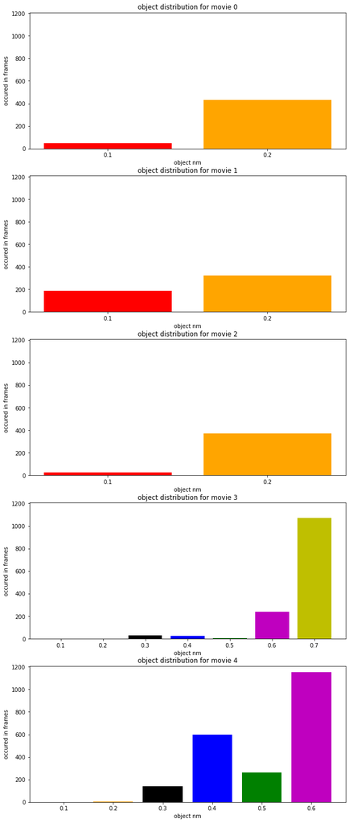

```python
fig, ax = plt.subplots(5,1, figsize=(10,20), sharey='all',
                       gridspec_kw=dict(left=0.1, right=0.9,
                                        bottom=0.0005, top=0.99995))
for i in range(len(json_dicts)):
    objects, counts = np.unique(objects_df[objects_df['movie'] == i]['nm'], return_counts=True)
    ax[i].bar(objects, counts, color=['r','orange','k','b', 'g', 'm', 'y'])
    ax[i].set_title(f'object distribution for movie {i}')
    ax[i].set_xlabel('object nm')
    ax[i].set_ylabel('occured in frames')
plt.show()
```

We can also see that objects 0.1 and 0.2 are almost not featured in movies 3-4. Maybe the explanation is that the probability of the objects to appear together is small.

#### More analysis:

I would have also liked to see when each object appears in the movie. This is done by plotting a timeline chart (where the x axis are the frames), and for each object in the movie, if it is shown, it'll have the value of it's 'nm', and if not then 0.

The idea is to see a correlation between objects, or to detect times in which there are no objects on screen. (the later case shouldn't be dismissed. The model should intake some data with no annotations.) I didn't do it since it ties back a bit to the distribution, and since there is a time constraint. here is an example made in excel:

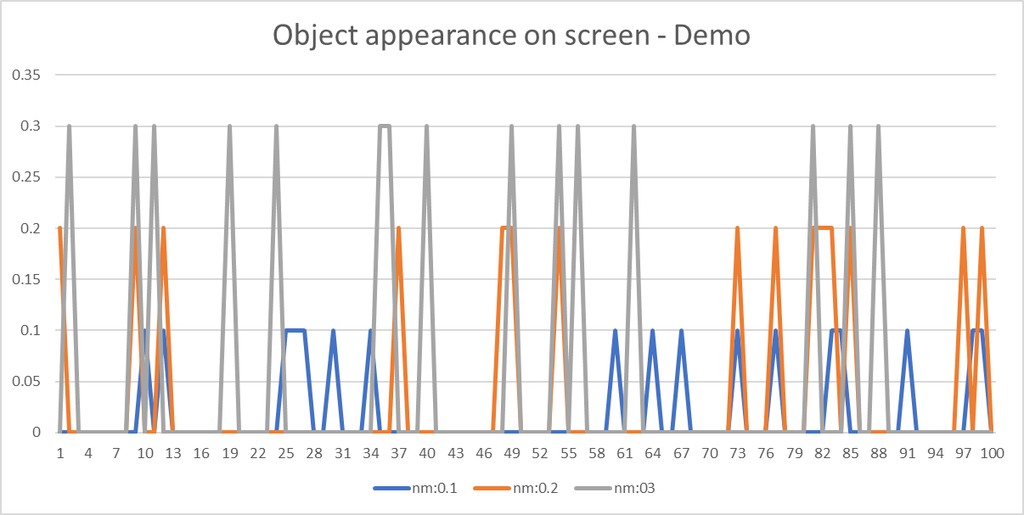

I would have also like to study the cutoff object - how many of them there are, of which type there is the most, etc.

Same for occlusion.

# Summary and suggestions

to summerize, due to the time and resource constraints and myself picking a dataset that doesn't contain huge amount of anomalies, would like to suggest some adjustments to enhance the dataset:

- Combine more objects together to try and challange the models.
- There are probably not enough data from these files to train a new model from scratch. It will need more.
- Try to show an even amount of each object. There is a large bias towards nm 0.2 and nm 0.6 for example.
- Try to include more frames without objects, so we could balance between situation where there is no data/objects to spot.
- Clean the frames that are defined as 'ignore_frame' or 'attr_key_frame'. If the movie contains a large amount if those, so not include it in the content for the models.
- If possible, change the shape of some of the objects from bBox to something more appropriate (maybe skeleton for presons), since the models are probably more adept in finding these objects with that type of shape, and because inconsistency is a bad thing.